# R-Fundamentals Part 3 solutions

D-Lab

3/30/2019

# Part 3 solutions

## **Challenge 1**

Where are you in your own research workflow? What are your strengths and weaknesses? What do you still need to learn?

## **Challenge 2**

1. Load the `iris` dataset.
2. Run `summary`, `describe`, `describeBy`, and `table` on iris.

```r
# 1.
load("../data-proc/data.RData")

# 2.
summary(iris)
```

```
##   Sepal.Length    Sepal.Width     Petal.Length    Petal.Width
##  Min.   :4.300   Min.   :2.000   Min.   :1.000   Min.   :0.100
##  1st Qu.:5.100   1st Qu.:2.800   1st Qu.:1.600   1st Qu.:0.300
##  Median :5.800   Median :3.000   Median :4.350   Median :1.300
##  Mean   :5.843   Mean   :3.057   Mean   :3.758   Mean   :1.199
##  3rd Qu.:6.400   3rd Qu.:3.300   3rd Qu.:5.100   3rd Qu.:1.800
##  Max.   :7.900   Max.   :4.400   Max.   :6.900   Max.   :2.500
##        Species
##  setosa    :50
##  versicolor:50
##  virginica :50
##
##
##
```

```r
summary(iris$Petal.Length)
```

```
##    Min. 1st Qu.  Median    Mean 3rd Qu.    Max.
##   1.000   1.600   4.350   3.758   5.100   6.900
```

```r
psych::describe(iris[, -5])
```

```
##              vars   n mean   sd median trimmed  mad min max range  skew
## Sepal.Length    1 150 5.84 0.83   5.80    5.81 1.04 4.3 7.9   3.6  0.31
## Sepal.Width     2 150 3.06 0.44   3.00    3.04 0.44 2.0 4.4   2.4  0.31
## Petal.Length    3 150 3.76 1.77   4.35    3.76 1.85 1.0 6.9   5.9 -0.27
## Petal.Width     4 150 1.20 0.76   1.30    1.18 1.04 0.1 2.5   2.4 -0.10
##              kurtosis   se
## Sepal.Length    -0.61 0.07
## Sepal.Width      0.14 0.04
## Petal.Length    -1.42 0.14
## Petal.Width     -1.36 0.06
```

```r
psych::describeBy(iris[, -5], group = iris$Species)
```

```
##
##  Descriptive statistics by group
## group: setosa
##              vars  n mean   sd median trimmed  mad min max range skew
## Sepal.Length    1 50 5.01 0.35    5.0    5.00 0.30 4.3 5.8   1.5 0.11
## Sepal.Width     2 50 3.43 0.38    3.4    3.42 0.37 2.3 4.4   2.1 0.04
## Petal.Length    3 50 1.46 0.17    1.5    1.46 0.15 1.0 1.9   0.9 0.10
## Petal.Width     4 50 0.25 0.11    0.2    0.24 0.00 0.1 0.6   0.5 1.18
##              kurtosis   se
## Sepal.Length    -0.45 0.05
## Sepal.Width      0.60 0.05
## Petal.Length     0.65 0.02
## Petal.Width      1.26 0.01
## --------------------------------------------------------
## group: versicolor
##              vars  n mean   sd median trimmed  mad min max range  skew
## Sepal.Length    1 50 5.94 0.52   5.90    5.94 0.52 4.9 7.0   2.1  0.10
## Sepal.Width     2 50 2.77 0.31   2.80    2.78 0.30 2.0 3.4   1.4 -0.34
## Petal.Length    3 50 4.26 0.47   4.35    4.29 0.52 3.0 5.1   2.1 -0.57
## Petal.Width     4 50 1.33 0.20   1.30    1.32 0.22 1.0 1.8   0.8 -0.03
##              kurtosis   se
## Sepal.Length    -0.69 0.07
## Sepal.Width     -0.55 0.04
## Petal.Length    -0.19 0.07
## Petal.Width     -0.59 0.03
## --------------------------------------------------------
## group: virginica
##              vars  n mean   sd median trimmed  mad min max range  skew
## Sepal.Length    1 50 6.59 0.64   6.50    6.57 0.59 4.9 7.9   3.0  0.11
## Sepal.Width     2 50 2.97 0.32   3.00    2.96 0.30 2.2 3.8   1.6  0.34
## Petal.Length    3 50 5.55 0.55   5.55    5.51 0.67 4.5 6.9   2.4  0.52
## Petal.Width     4 50 2.03 0.27   2.00    2.03 0.30 1.4 2.5   1.1 -0.12
##              kurtosis   se
## Sepal.Length    -0.20 0.09
## Sepal.Width      0.38 0.05
## Petal.Length    -0.37 0.08
## Petal.Width     -0.75 0.04
```

```r
table(iris$Species)
```

```
##
##     setosa versicolor  virginica
##         50         50         50
```

## **Challenge 3**

1. Create a histogram of one of the numeric variables from the `iris` dataset.

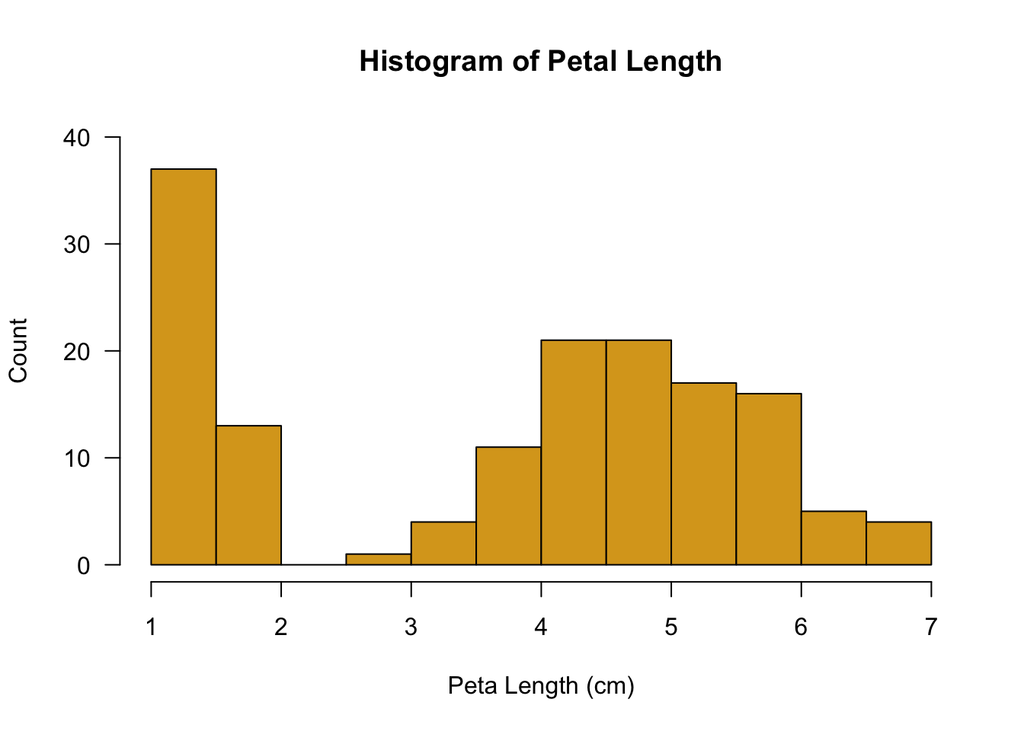

```r
hist(iris$Petal.Length,
     col = "goldenrod",
     main = "Histogram of Petal Length",
     xlab = "Peta Length (cm)",
     ylab = "Count",
     xlim = c(1, 7),
     ylim = c(0, 40),
     las = 1)
```

## **Challenge 4**

1. Create boxplots for one of the numeric variables in the `iris` dataset as parsed by Species.

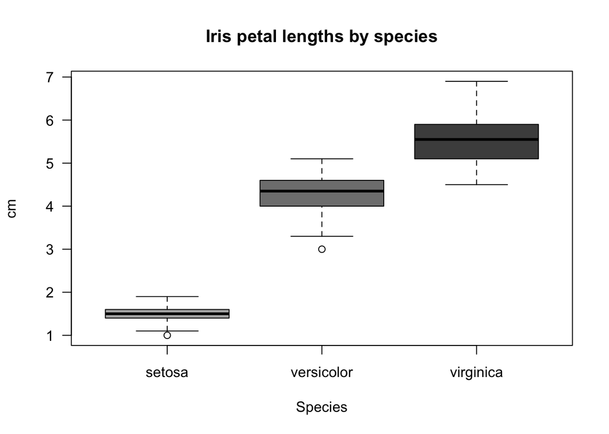

```r
boxplot(iris$Petal.Length ~ iris$Species,
        col = c("gray70", "gray50", "gray30"),
        main = "Iris petal lengths by species",
        xlab = "Species",
        ylab = "cm",
        las = 1)
```

## **Challenge 5**

1. Using the `iris` dataset, plot two numeric variables in a scatterplot.

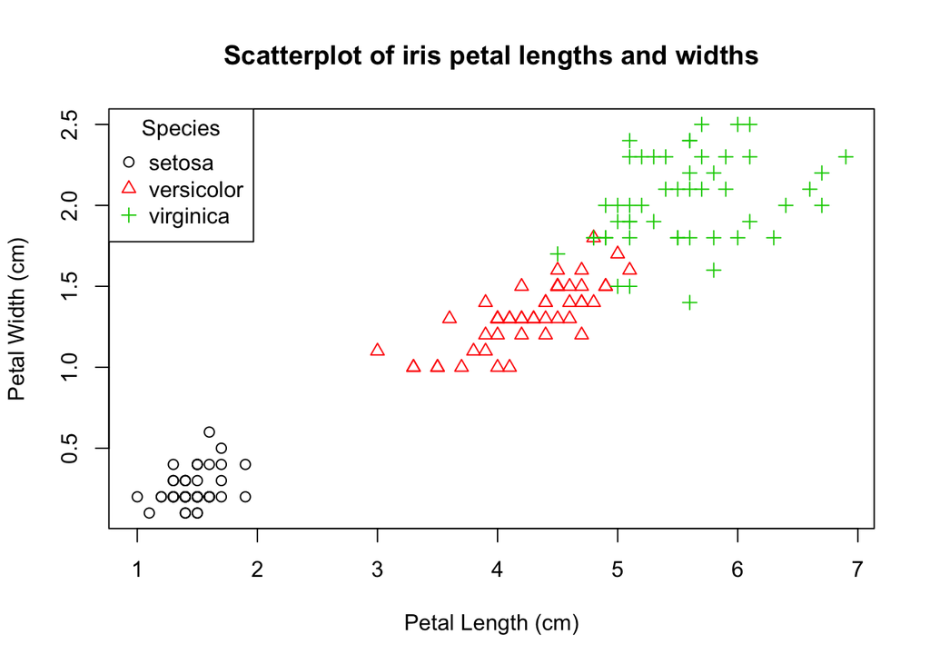

```r
plot(x = iris$Petal.Length,
     y = iris$Petal.Width,
     main = "Scatterplot of iris petal lengths and widths",
     xlab = "Petal Length (cm)",
     ylab = "Petal Width (cm)",
     col = as.integer(iris$Species),
     pch = as.integer(iris$Species))
legend("topleft", inset = 0, title = "Species", cex = 1,
       c("setosa", "versicolor", "virginica"),
       col = c(1,2,3), pch = c(1,2,3),
       horiz = FALSE)
```

## **Challenge 6**

1. Create a ggplot histogram of one of the variables from the sleep_VIM dataset.

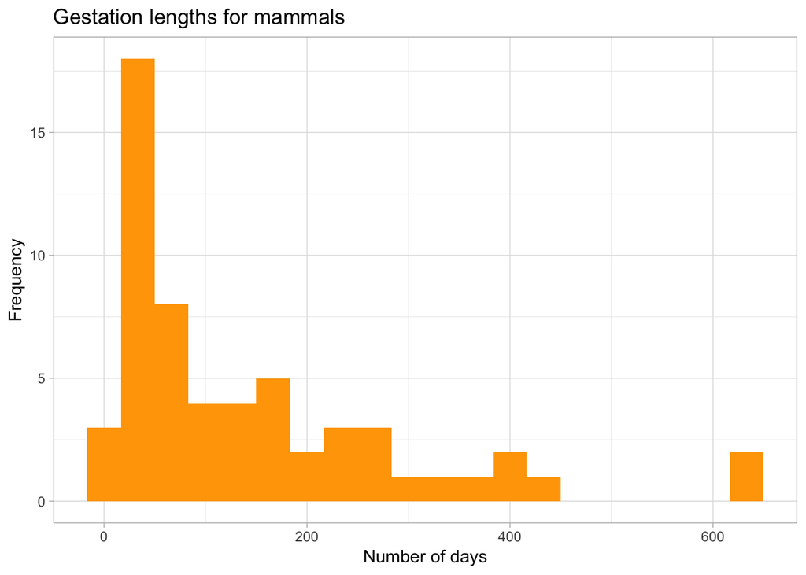

```r
library(ggplot2)
ggplot2::ggplot(sleep, aes(x = Gest)) +
  geom_histogram(fill = "orange", bins = 20) +
  ggtitle("Gestation lengths for mammals") +
  xlab("Number of days") +
  ylab("Frequency") +
  theme_light()
```

## **Challenge 7**

1. Create ggplot boxplots for mpg for 4, 6, and 8 cylinder cars from the mtcars dataset.

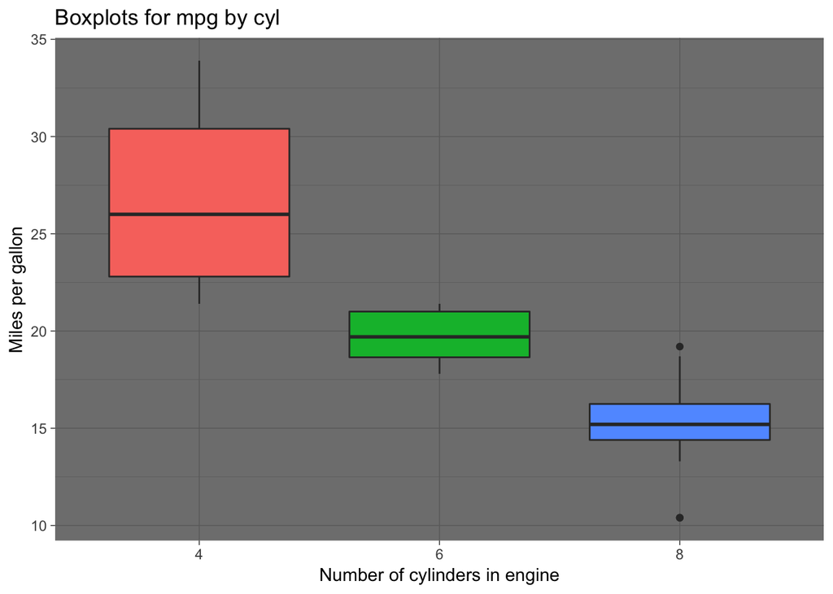

```r
ggplot(mtcars, aes(x = as.factor(cyl), y = mpg, fill = as.factor(cyl))) +
  geom_boxplot() +
  ggtitle("Boxplots for mpg by cyl") +
  xlab("Number of cylinders in engine") +
  ylab("Miles per gallon") +
  theme_dark() +
  guides(fill = F)
```

## **Challenge 8**

```r
# Change legend position: top, bottom, left, right
theme(legend.position = "top",

      # Change horizontal justification and size of plot title
      plot.title = element_text(hjust = 0.5, size = 20),

      # Change size of the legend title
      legend.title = element_text(size = 10),

      # Change size of the legend text
      legend.text = element_text(size = 5),

      # Change the angle and horizontal justification of the x-axis text
      axis.text.x = element_text(angle = 45, hjust = 1))
```

[output not shown]

## **Challenge 9**

1. What are the assumptions for a t-test?
2. Fit a t-test for Petal Lengths between iris versicolor and virginica species.
3. What does this result mean?

```r
?t.test

# 1.
https://en.wikipedia.org/wiki/Student%27s_t-test#Assumptions

# 2. subset!
versicolor = iris[iris$Species == "versicolor", ]
virginica = iris[iris$Species == "virginica", ]

t.test(versicolor$Petal.Length, virginica$Petal.Length)
```

[output not shown]

## **Challenge 10**

1. What are the assumptions for a one-way analysis of variance?
2. Use the `mtcars` dataset to perform an ANOVA and TukeyHSD test for mpg between the three cyl sizes (4, 6, and 8).

```r
# 1.
# https://en.wikipedia.org/wiki/One-way_analysis_of_variance#Assumptions

# 2.
mtcars_aov = aov(mpg ~ as.factor(cyl), data = mtcars)
summary(mtcars_aov)
```

```
##                Df Sum Sq Mean Sq F value   Pr(>F)
## as.factor(cyl)  2  824.8   412.4    39.7 4.98e-09 ***
## Residuals      29  301.3    10.4
## ---
## Signif. codes:  0 '***' 0.001 '**' 0.01 '*' 0.05 '.' 0.1 ' ' 1
```

```r
TukeyHSD(mtcars_aov)
```

```
##   Tukey multiple comparisons of means
##     95% family-wise confidence level
##
## Fit: aov(formula = mpg ~ as.factor(cyl), data = mtcars)
##
## $`as.factor(cyl)`
##           diff        lwr        upr     p adj
## 6-4  -6.920779 -10.769350 -3.0722086 0.0003424
## 8-4 -11.563636 -14.770779 -8.3564942 0.0000000
## 8-6  -4.642857  -8.327583 -0.9581313 0.0112287
```